# R Notebook

```r
curve2 <- function(func, from, to, col = "black", lty = 1, lwd = 1, add = FALSE, xlab = NULL, ylab = NULL, xlim = NULL, ylim = NULL, main = NULL, ...) {
    f <- function(x) func(x)
    curve(expr = f, from = from, to = to, col = col, lty = lty, lwd = lwd, add = add, xlab = xlab, ylab = ylab, xlim = xlim, ylim = ylim, main = main, ... = ...)
}
```

# Load The Data

```r
td.notions <- c("CodeClimate", "Codiga", "SonarQube")
data <- NULL

for (tdn in td.notions) {
  temp <- read.csv(file = paste0("data/", tdn, "_debt_results.csv"), header = TRUE)
  temp$Notion <- tdn
  data <- rbind(data, temp)
}
data$Model_type <- factor(x = data$Model_type, levels = unique(data$Model_type))
data$PCA <- as.logical(data$PCA)
data$Domain <- as.logical(data$Domain)
data$Notion <- factor(x = data$Notion, levels = unique(data$Notion))
temp <- NULL
```

# Which Notion Can We Predict Best?

We know that the TD notions of Codiga and SonarQube differ (e.g., it is much more common to have a large value for the latter). This makes them difficult to compare. However, we can transform the corpus’ projects’ TD into CDFs and *normalize* the predicted values. In other words, the CDF-transformation will give us results that we can compare.

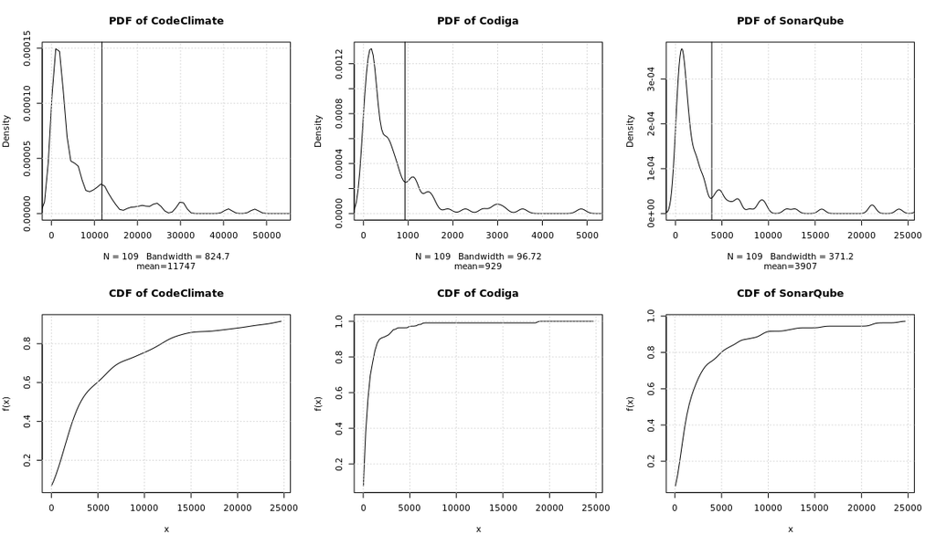

```r
par(mfrow = c(2, 3))
TD <- read.csv(file = "data/TD.csv", header = TRUE)

for (tdn in td.notions) {
  temp <- TD[[paste0(tdn, "_debt")]]
  plot(density(temp, bw = "SJ"), xlim = c(0, quantile(temp, 0.975)), main = paste0("PDF of ", tdn), sub = paste0("mean=", round(mean(temp))))
  abline(v = mean(temp))
  grid()
}

cdfs <- list()
for (tdn in td.notions) {
  # We'll estimate a density and then take its CDF
  cdfs[[tdn]] <- (function() {
    temp <- TD[[paste0(tdn, "_debt")]]
    bw <- bw.SJ(x = temp)
    Vectorize(function(x) 1 / length(temp) * sum(pnorm((x - temp) / bw)))
  })()

  curve2(func = cdfs[[tdn]], from = min(TD[[paste0(tdn, "_debt")]]), to = quantile(temp, 0.975), main = paste0("CDF of ", tdn))
  grid()
}
```

```r
temp <- NULL
```

Now we got **four** different flavors per TD notion: With/without Domain and with/without performing PCA on the data. We also obtained $1,000$ RMSEs/MAEs per flavor. If we consider the MAE here, it is the mean absolute difference between the actual and predicted TD. If we take the obtained MAEs and convert them into probabilities using the corresponding CDFs, we will get a good idea for each flavor of estimator whether it predicts low or high deviations. Using the CDFs also allows us then to compare these results, which would otherwise not have been possible. The last dimensions we need to consider here is the used **model**.

```r
comparison <- NULL
use.grid <- expand.grid(list(keep_Domain=c(TRUE, FALSE), do_PCA=c(TRUE,FALSE)))

for (tdn in td.notions) {
  for (model_type in levels(data$Model_type)) {
    temp <- `rownames<-`(x = matrix(nrow = 1, ncol = 4), value = paste0(tdn, "_", model_type))

    use.labels <- c()
    for (idx in 1:nrow(use.grid)) {
      row <- use.grid[idx,]
      use.labels <- c(use.labels, paste0(if (row$keep_Domain) "WithDomain" else "NoDomain", "_", if (row$do_PCA) "UsePCA" else "NoPCA"))
      temp[1, idx] <- mean(cdfs[[tdn]](
        data[data$Notion == tdn & data$Model_type == model_type & data$Domain == row$keep_Domain & data$PCA == row$do_PCA,]$MAE))
    }

    comparison <- rbind(comparison, `colnames<-`(x = temp, value = use.labels))
  }
}

comparison
```

```
                WithDomain_UsePCA NoDomain_UsePCA WithDomain_NoPCA NoDomain_NoPCA
CodeClimate_RF          0.7606750       0.7660496        0.7452672      0.7519722
CodeClimate_XGB         0.7498625       0.7581327        0.7086790      0.7194362
CodeClimate_MLP         0.9056478       0.9087426        0.9162333      0.9183945
CodeClimate_LR          0.9328974       0.9311435        0.9530537      0.9524264
Codiga_RF               0.6795504       0.6834638        0.6536617      0.6601129
Codiga_XGB              0.6525374       0.6550226        0.5765633      0.5856857
Codiga_MLP              0.8165407       0.8165647        0.8252067      0.8308815
Codiga_LR               0.8253077       0.8213767        0.8698335      0.8683150
SonarQube_RF            0.7396159       0.7412417        0.7301272      0.7341624
SonarQube_XGB           0.7335765       0.7376694        0.7178658      0.7215078
SonarQube_MLP           0.8185164       0.8204274        0.8366887      0.8390546
SonarQube_LR            0.8076266       0.8096504        0.9079272      0.9083246
```

The above results tell us the following: the lower the average value, the better the flavor. The best value for CodeClimate is **XGB**, **including domain**, **not doing PCA** ($\approx0.709$). The same flavor is the best for Codiga ($\approx0.577$), as well as SonarQube ($\approx0.718$).

That also means, Codiga $>$ CodeClimate $\approx$ SonarQube in terms of what we can predict best.

Let’s show the distributions of the original and CDF-normalized MAEs:

```r
par(mfrow = c(4,3))

for (tdn in td.notions) {
  temp <- data[data$Notion == tdn & data$Model_type == "XGB" & data$Domain == TRUE & data$PCA == FALSE,]$MAE
  temp.test <- shapiro.test(x = temp)
  plot(density(temp, bw = "SJ"), main = paste0(tdn, " (org)"), sub = paste0("Shapiro W=", round(temp.test$statistic, 3), ", p-value=", temp.test$p.value))
  abline(v = mean(temp))
  grid()
}

for (tdn in td.notions) {
  plot(ecdf(data[data$Notion == tdn & data$Model_type == "XGB" & data$Domain == TRUE & data$PCA == FALSE,]$MAE),
    main = paste0(tdn, " (CDF of org)"))
  grid()
}
```

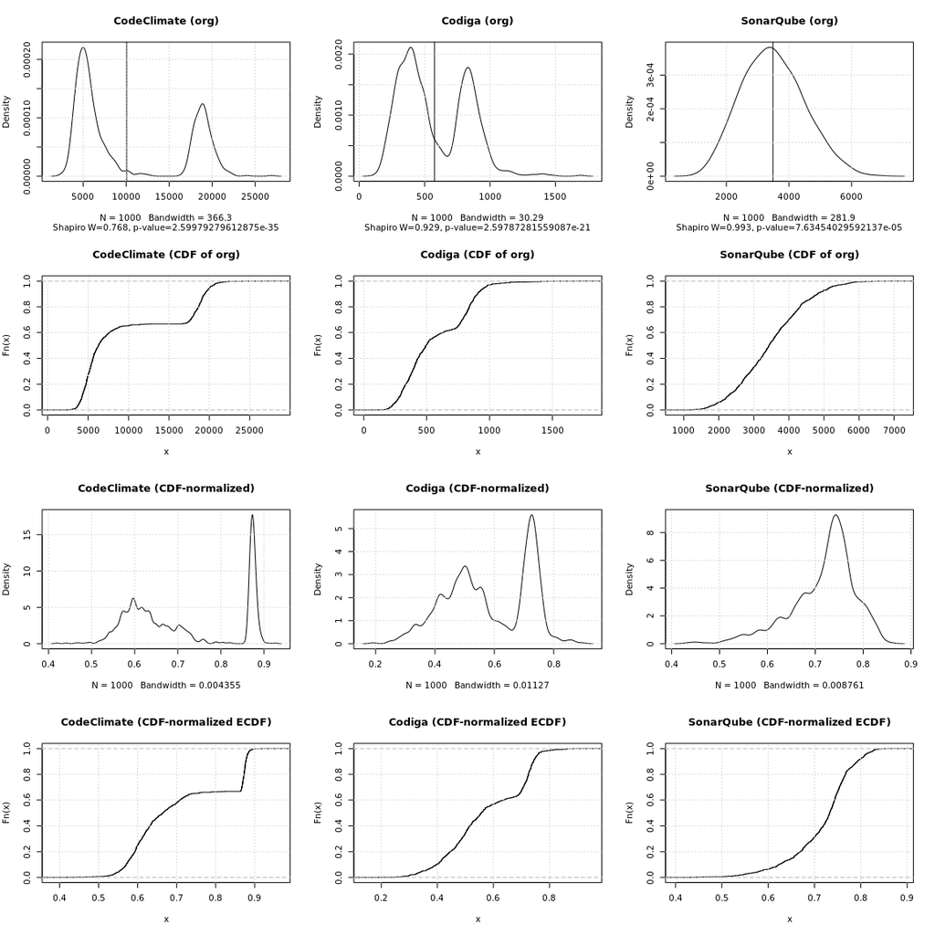

```r
for (tdn in td.notions) {
  plot(density(cdfs[[tdn]](
    data[data$Notion == tdn & data$Model_type == "XGB" & data$Domain == TRUE & data$PCA == FALSE,]$MAE), bw = "SJ"),
    main = paste0(tdn, " (CDF-normalized)"))
  grid()
}

for (tdn in td.notions) {
  plot(ecdf(cdfs[[tdn]](
    data[data$Notion == tdn & data$Model_type == "XGB" & data$Domain == TRUE & data$PCA == FALSE,]$MAE)),
    main = paste0(tdn, " (CDF-normalized ECDF)"))
  grid()
}
```

# Continuous Confidence Intervals

```r
temp <- data[data$Notion == "Codiga" & data$Model_type == "XGB" & data$Domain == TRUE & data$PCA == FALSE,]$MAE
(m_ <- mean(temp))
```

```
[1] 575.0445
```

```r
(sd_ <- sd(temp))
```

```
[1] 255.6866
```

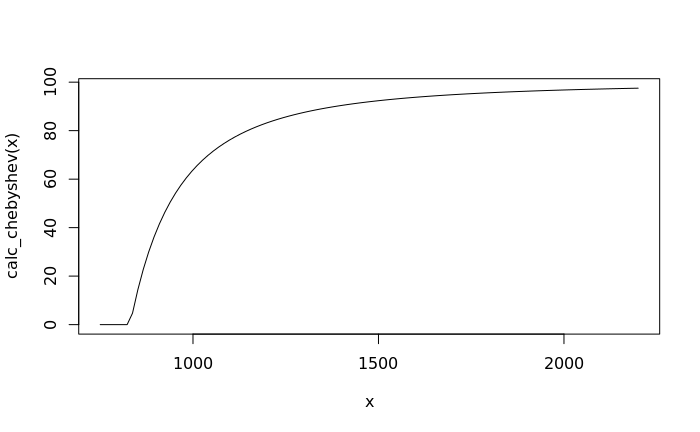

```r
calc_chebyshev <- Vectorize(function(mae) {
  mae <- max(m_, mae)
  diff <- abs(m_ - mae)
  k2 <- (diff / sd_)^2
  100 * (1 - 1 / max(1, k2))
})

curve(calc_chebyshev, 750, 2200)
```

```r
#plot(ecdf(temp))
bw <- bw.SJ(x = temp)
tempf <- Vectorize(function(x) 1 / length(temp) * sum(pnorm((x - temp) / bw)))
curve2(tempf, 0, 1500)

tempf <- Vectorize(function(diff) {
  diff <- abs(diff)
  #diff <- abs(m_ - x)
  k2 <- (diff / sd_)^2
  1 - 1 / max(1, k2)
})

curve2(tempf, 0, 2000, add = TRUE)
```

[output not shown]

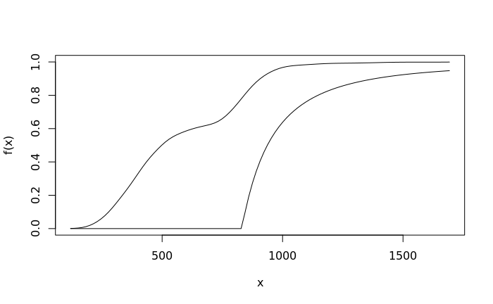

```r
bw <- bw.SJ(x = temp)
tempf <- Vectorize(function(x) 1 / length(temp) * sum(pnorm((x - temp) / bw)))

curve2(tempf, min(temp), max(temp))

calc_chebyshev <- Vectorize(function(mae) {
  mae <- max(m_, mae)
  diff <- abs(m_ - mae)
  k2 <- (diff / sd_)^2
  1 - 1 / max(1, k2)
})
curve(calc_chebyshev, min(temp), max(temp), add=TRUE)
```

The following table shows the three-sigma rule, as well as Chebyshev’s rule (I only include the three-sigma rule as demonstration, but it is not applicable here). It shows that, for example, only for very low confidences, we expect our champion model to deviate rather slightly from the expected mean MAE. For example, our confidence is only $5$% that the predictions for the type of champion model on Codiga’s TD notion deviates between $312$ and $837$ around a mean of $575$. In other words, even the champion model is “usually” (on average) of by $575$. However, it may be off less (down to $312$) or more (up to $837$). We can “guarantee” this with a confidence of 5%.

Such a low confidence has no real practical usage. So, if we look at a more reasonable example, say, $90$%, the deviation from the expectation (mean) must be more extreme. Note that I limited the models so they can only predict values $>=0$. So with $90$% confidence, the deviation from the actual technical debt, for Codiga, is $<\approx1,383$.

Recall that a typical value for Codiga’s notion of technical debt is $929$. In other words, running Codiga on a random project will on average yield a TD of $929$. If we’re off by more than $1,300$, it could mean that we predict (roughly) that a project has no TD when it actually has TD, or that we predict the TD to be much higher. These are just examples off how “off” we could be with those $90$%.

But here is where it also gets interesting. Suppose you are happy with a lower confidence, just to get “ballpark” kind of figures. So if, e.g., $50$% confidence is enough, this predictor might become useful. Let’s say you are dealing with projects that usually have a very high TD, then being off by $\approx1,000$ is perhaps acceptable for getting a first quick impression. Remember that this here is a trade-off; evaluating TD is perhaps really expensive in real-life, as you need experts who have to do this qualitatively, evaluating lots of unstructured data [@Matsubara2021].

```r
library(dplyr)

temp.df <- data.frame(
  Confidence = sort(c(seq(from = 5, to = 95, by = 10), 50, 80, 90, 68.27, 95.45, 97.5, 98))
) %>% group_by(Confidence) %>% summarize(
  Low = max(0, round(qnorm(c(.5 - Confidence / 200), mean = mean(temp), sd = sd(temp)), 4)),
  Mean1 = round(mean(temp), 2),
  High = round(qnorm(c(.5 + Confidence / 200), mean = mean(temp), sd = sd(temp)), 4),
  Chebyshev_Low = max(0, round(mean(temp) - sd(temp) * sqrt(1 / (1 - Confidence / 100)), 4)),
  Mean2 = round(mean(temp), 2),
  Chebyshev_High = round(mean(temp) + sd(temp) * sqrt(1 / (1 - Confidence / 100)), 4),
  .groups = "drop")

if (interactive()) {
  temp.df
} else {
  knitr::kable(x = temp.df)
}
```

| Confidence | Low | Mean1 | High | Chebyshev_Low | Mean2 | Chebyshev_High |
| --- | --- | --- | --- | --- | --- | --- |
| 5.00 | 559.0113 | 575.04 | 591.0778 | 312.7156 | 575.04 | 837.3734 |
| 15.00 | 526.6895 | 575.04 | 623.3996 | 297.7135 | 575.04 | 852.3756 |
| 25.00 | 493.5727 | 575.04 | 656.5164 | 279.8031 | 575.04 | 870.2860 |
| 35.00 | 459.0236 | 575.04 | 691.0654 | 257.9044 | 575.04 | 892.1847 |
| 45.00 | 422.2053 | 575.04 | 727.8838 | 230.2768 | 575.04 | 919.8123 |
| 50.00 | 402.5866 | 575.04 | 747.5025 | 213.4491 | 575.04 | 936.6400 |
| 55.00 | 381.8951 | 575.04 | 768.1940 | 193.8895 | 575.04 | 956.1996 |
| 65.00 | 336.0826 | 575.04 | 814.0065 | 142.8553 | 575.04 | 1007.2338 |
| 68.27 | 319.3524 | 575.04 | 830.7367 | 121.1312 | 575.04 | 1028.9578 |
| 75.00 | 280.9156 | 575.04 | 869.1734 | 63.6714 | 575.04 | 1086.4177 |

[output cut: 7 more lines]